# Creating Publication-Quality Graphics with ggplot2

## Statistical Functions

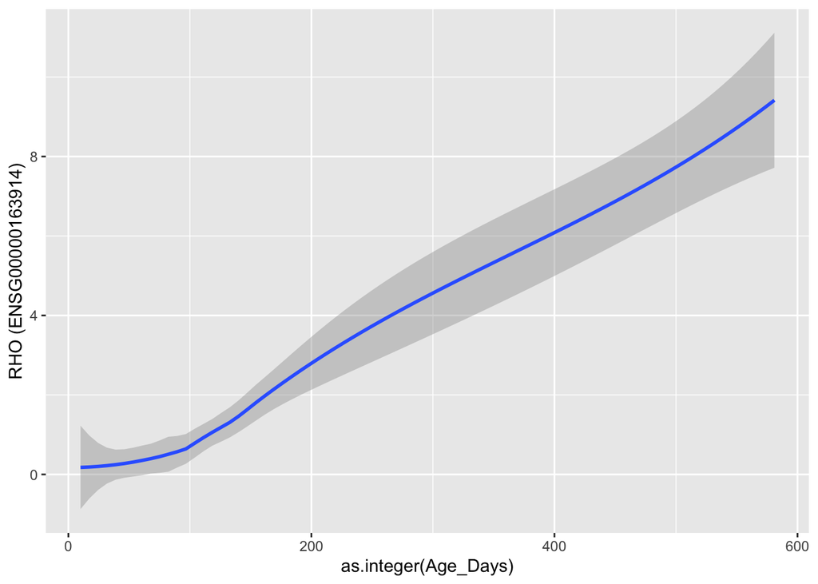

```r
eiad_meta_exp %>%
  mutate(Age_Days = as.integer(Age_Days)) %>%
  filter(Tissue == 'Retina', !is.na(Age_Days)) %>%
  ggplot(aes(x=as.integer(Age_Days),
             y=`RHO (ENSG00000163914)`)) +
  geom_smooth()
```

Now perhaps we would like to see the linear trend. What is plotted in a “loess” which is a smoothed curve across the data.

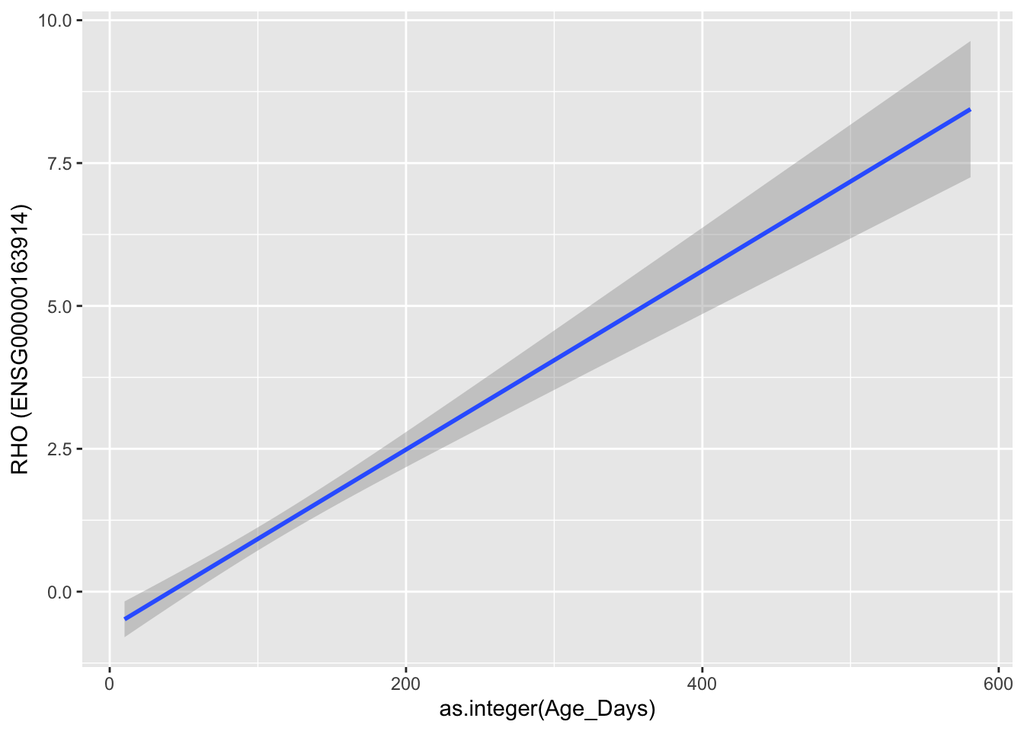

```r
eiad_meta_exp %>%
  mutate(Age_Days = as.integer(Age_Days)) %>%
  filter(Tissue == 'Retina', !is.na(Age_Days)) %>%
  ggplot(aes(x=as.integer(Age_Days),
             y=`RHO (ENSG00000163914)`)) +
  geom_smooth(method = 'lm')
```

## Multiple Layers

How do we make the dots come back….any ideas?

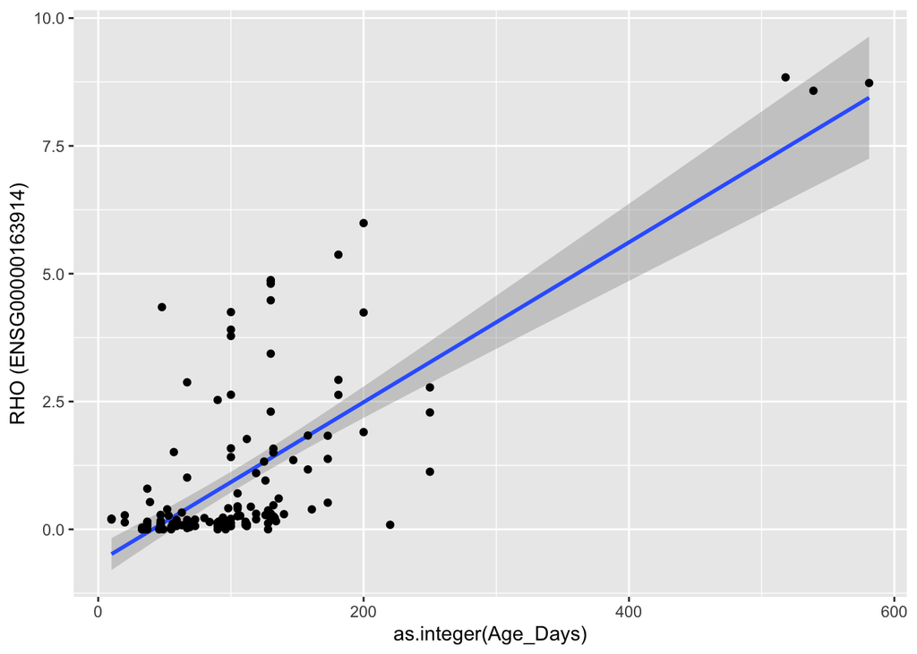

```r
eiad_meta_exp %>%
  mutate(Age_Days = as.integer(Age_Days)) %>%
  filter(Tissue == 'Retina', !is.na(Age_Days)) %>%
  ggplot(aes(x=as.integer(Age_Days),
             y=`RHO (ENSG00000163914)`)) +
  geom_smooth(method = 'lm') +
  geom_point()
```

## Order of operations

How do we get the line in FRONT of the dots?????

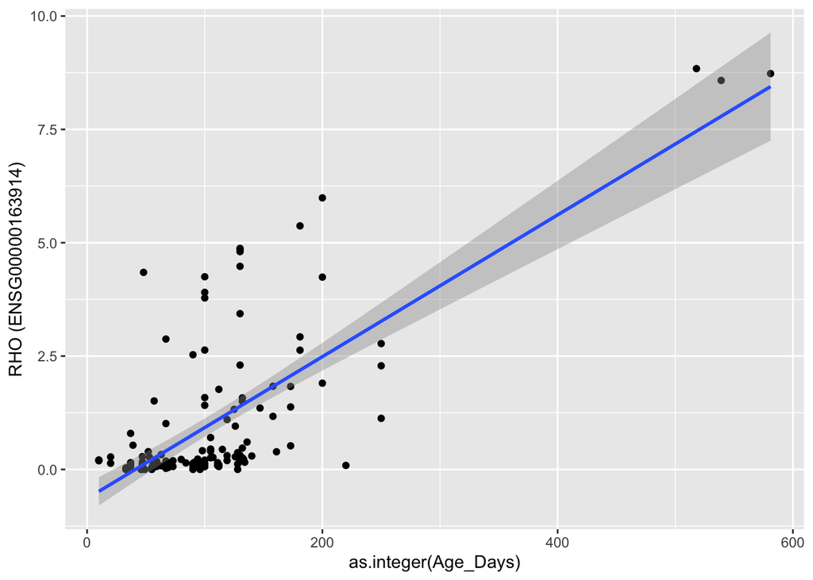

```r
eiad_meta_exp %>%
  mutate(Age_Days = as.integer(Age_Days)) %>%
  filter(Tissue == 'Retina', !is.na(Age_Days)) %>%
  ggplot(aes(x=as.integer(Age_Days),
             y=`RHO (ENSG00000163914)`)) +
  geom_point() +
  geom_smooth(method = 'lm')
```

# Color aesthetics

Now we have different KINDS of retina here. More specifically we have three sources of retina (ESC, organoid, primary tissue). How do we separate the lines for each group?

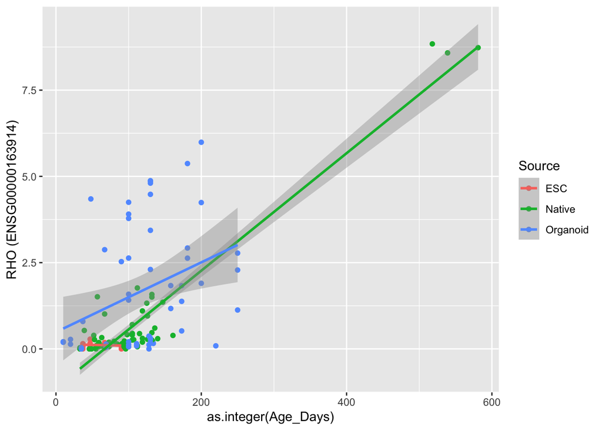

```r
eiad_meta_exp %>%
  mutate(Age_Days = as.integer(Age_Days)) %>%
  filter(Tissue == 'Retina', !is.na(Age_Days)) %>%
  ggplot(aes(x=as.integer(Age_Days),
             y=`RHO (ENSG00000163914)`,
             color = Source)) +
  geom_point() + geom_smooth(method = 'lm')
```

# Where the aes goes is very important

This is visually a lot to look at…what if you want to just color the lines?

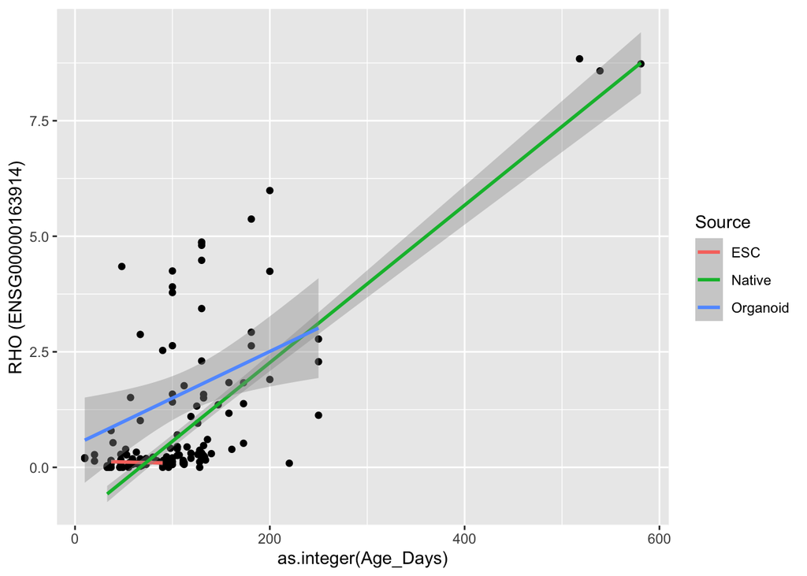

```r
eiad_meta_exp %>%
  mutate(Age_Days = as.integer(Age_Days)) %>%
  filter(Tissue == 'Retina', !is.na(Age_Days)) %>%
  ggplot(aes(x=as.integer(Age_Days),
             y=`RHO (ENSG00000163914)`)) +
  geom_point() +
  geom_smooth(aes(color = Source), method = 'lm')
```